# Course Project - Coursera Practical Machine Learning.

Author: Himansu Sahoo

Date : September 25, 2015

```r
getwd() # current working directory
```

```
## [1] "/Users/himanapple/Desktop/DataScience/Tutorial/coursera-datascience-project"
```

```r
ls() # list of objects in the environment
```

```
## character(0)
```

```r
iris_data <- iris
```

### Project Description

In this project, we will use data from accelerometers on the belt, forearm, arm, and dumbell of 6 participants. They were asked to perform barbell lifts correctly and incorrectly in 5 different ways.

The dataset is Weight Lifting Exercise Dataset.

The training data for this project are available here: https://d396qusza40orc.cloudfront.net/predmachlearn/pml-training.csv

The test data are available here: https://d396qusza40orc.cloudfront.net/predmachlearn/pml-testing.csv

The goal of your project is to predict the manner in which they did the exercise. This is the “classe” variable in the training set. You may use any of the other variables to predict with.

### Get training and testing dataset

```r
rawtrain_data <- read.csv("pml-training.csv", na.strings=c("NA", "NAN", ""))
rawtest_data <- read.csv("pml-testing.csv", na.strings=c("NA", "NAN", ""))
dim(rawtrain_data)
```

```
## [1] 19622   160
```

```r
dim(rawtest_data)
```

```
## [1]  20 160
```

### Variable Selection

The training dataset contains 19,622 observations and 160 variables. The last variable “classe” is the target variable for our model. Most of the columns have lot sof missing values (NA), we will remove those columns while building our model.

```r
train_noNA <- rawtrain_data[ , colSums(is.na(rawtrain_data)) == 0]
test_noNA <- rawtest_data[ , colSums(is.na(rawtest_data)) == 0]
dim(train_noNA)
```

```
## [1] 19622    60
```

```r
dim(test_noNA)
```

```
## [1] 20 60
```

The dataset has now 60 variables. We will also remove the variables like X, user_name, timestamp, window which can’t be used as predictors.

```r
remove_cols <- grepl("X|user_name|timestamp|window", colnames(train_noNA))
train_data <- train_noNA[ , !remove_cols]
test_data <- test_noNA[ , !remove_cols]
#dim(train_data)
#dim(test_data)
```

After variable selection, we are now left with 53 variables in the dataset. There are both numeric and integer variables. The last variable “classe” is the target variable. The is a factor variable with 5 levels.

### Explore the training dataset

```r
dim(train_data)
```

```
## [1] 19622    53
```

```r
names(train_data) # names of the variables
```

```
##  [1] "roll_belt"            "pitch_belt"           "yaw_belt"
##  [4] "total_accel_belt"     "gyros_belt_x"         "gyros_belt_y"
##  [7] "gyros_belt_z"         "accel_belt_x"         "accel_belt_y"
## [10] "accel_belt_z"         "magnet_belt_x"        "magnet_belt_y"
## [13] "magnet_belt_z"        "roll_arm"             "pitch_arm"
## [16] "yaw_arm"              "total_accel_arm"      "gyros_arm_x"
## [19] "gyros_arm_y"          "gyros_arm_z"          "accel_arm_x"
## [22] "accel_arm_y"          "accel_arm_z"          "magnet_arm_x"
## [25] "magnet_arm_y"         "magnet_arm_z"         "roll_dumbbell"
## [28] "pitch_dumbbell"       "yaw_dumbbell"         "total_accel_dumbbell"
## [31] "gyros_dumbbell_x"     "gyros_dumbbell_y"     "gyros_dumbbell_z"
## [34] "accel_dumbbell_x"     "accel_dumbbell_y"     "accel_dumbbell_z"
## [37] "magnet_dumbbell_x"    "magnet_dumbbell_y"    "magnet_dumbbell_z"
## [40] "roll_forearm"         "pitch_forearm"        "yaw_forearm"
## [43] "total_accel_forearm"  "gyros_forearm_x"      "gyros_forearm_y"
## [46] "gyros_forearm_z"      "accel_forearm_x"      "accel_forearm_y"
## [49] "accel_forearm_z"      "magnet_forearm_x"     "magnet_forearm_y"
## [52] "magnet_forearm_z"     "classe"
```

### Explore the Target (dependent) variable

```r
class(train_data$classe) # whether numeric or factor
```

```
## [1] "factor"
```

```r
str(train_data$classe) # full description
```

```
##  Factor w/ 5 levels "A","B","C","D",..: 1 1 1 1 1 1 1 1 1 1 ...
```

```r
levels(train_data$classe) # levels of the factor variable
```

```
## [1] "A" "B" "C" "D" "E"
```

```r
table(train_data$classe) # statistics of each level
```

```
##
##    A    B    C    D    E
## 5580 3797 3422 3216 3607
```

```r
prop.table(table(train_data$classe))
```

```
##
##         A         B         C         D         E
## 0.2843747 0.1935073 0.1743961 0.1638977 0.1838243
```

### Exploratory data analysis

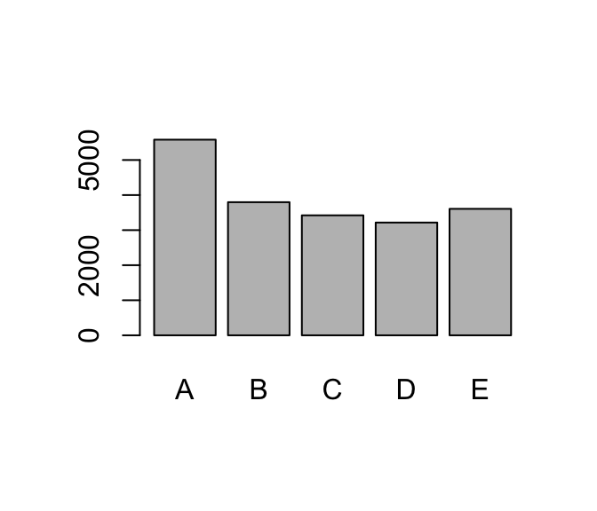

```r
#hist(iris_data$Sepal.Length, breaks=20, xlim=c(4,8))
#hist(iris_data$Sepal.Width, breaks=15, xlim=c(1.5,4.5), col="red")
#hist(iris_data$Petal.Length, breaks=20, xlim=c(1,7))
#hist(iris_data$Petal.Width, breaks=15, xlim=c(0,3), col="blue", xlab="Petal Width", ylab="# of entries", main="Histogram of Petal Width")
barplot(table(train_data$classe))
```

```r
#boxplot(iris_data$Sepal.Length, ylab="Sepal Length")
#boxplot(iris_data$Sepal.Width, ylab="Sepal Width", main="Box plot of Sepal.Width")
#boxplot(iris_data$Petal.Length, ylab="Petal.Length", main="Box plot of Petal.Length", col="red")
#boxplot(iris_data$Petal.Width, ylab="Petal.Width", main="Box plot of Petal.Width", col="blue")
```

```r
#iris_data[1:3,1:4]
#cor(iris_data[,1:4])
#cor(iris_data$Sepal.Length, iris_data$Petal.Length)
#pairs(iris_data[,1:4], col=iris_data$Species)
```

```r
#plot(x=iris_data$Petal.Length, y=iris_data$Petal.Width, col=iris_data$Species)
library(ggplot2)
#qplot(Petal.Length, Petal.Width, colour=Species, data=iris_data)
```

```r
library(caret)
set.seed(110)
inTrain <- createDataPartition(y=iris_data$Species, p=0.75, list=FALSE)
# inTrain is a matrix
class(inTrain)
```

```
## [1] "matrix"
```

```r
dim(inTrain)
```

```
## [1] 114   1
```

```r
train_data <- iris_data[inTrain,]
test_data <- iris_data[-inTrain,]
```

```r
dim(train_data)
```

```
## [1] 114   5
```

```r
cat("train : dimension :  ", dim(train_data) , "\n")
```

```
## train : dimension :   114 5
```

```r
table(train_data$Species)
```

```
##
##     setosa versicolor  virginica
##         38         38         38
```

```r
prop.table(table(train_data$Species))
```

```
##
##     setosa versicolor  virginica
##  0.3333333  0.3333333  0.3333333
```

```r
dim(test_data)
```

```
## [1] 36  5
```

```r
cat("test : dimension :  ", dim(test_data) , "\n")
```

```
## test : dimension :   36 5
```

```r
table(test_data$Species)
```

```
##
##     setosa versicolor  virginica
##         12         12         12
```

```r
prop.table(table(test_data$Species))
```

```
##
##     setosa versicolor  virginica
##  0.3333333  0.3333333  0.3333333
```

```r
train_per <- (nrow(train_data)/nrow(iris_data))*100
test_per <- (nrow(test_data)/nrow(iris_data))*100
cat("******** training dataset is :  ", train_per, "% \n")
```

```
## ******** training dataset is :   76 %
```

```r
cat("******** testing dataset is :  ", test_per, "% \n")
```

```
## ******** testing dataset is :   24 %
```